# Segmentation: First Passage Time

## The `ltraj` Data Format

Unfortunately the `adehabitatLT` does not work too well #' with simple feature projected data, but rather with the now outdates #' “Spatial Points” data type.

```r
library(adehabitatLT)
#' library(sf)
#' library(plyr)
```

In order to fit the `fpt` function, we first need to:

1 - make our data spatial (`sf`)

2 - convert our data to `SpatialPoints` format #' (`sp` which is automatically installed and loaded with the #' `adehabitatLT` package).

```r
myelk_sp <- myelk |>
#'   st_as_sf(coords=c("lon","lat"), crs= 4326) |>
#'   st_transform(32611) |>
#'   st_cast("POINT") |>
#'   as_Spatial()
```

We can now use the `as.ltraj` function to convert out data #' into ltraj format.

```r
myelk_traj <- as.ltraj(coordinates(myelk_sp),
#'                        date = myelk$datetime,
#'                        id = myelk$id)
#'
#' summary(myelk_traj)
```

```
##     id burst nb.reloc NAs          date.begin            date.end
#' ## 1 YL96  YL96     4129   0 2004-03-29 17:00:00 2004-10-17 09:00:00
```

Note, the `ltraj` data type is good for processing #' multiple individuals - and even multiple “bursts” (subsets of data) per #' individual. We won’t’use that functionality here.

We can use the `head` function to look at the ltraj data #' table for this individual. Note that in converting to `ltraj` #' many of the metrics that we also obtained are computed (step lengths, #' turning angles, etc.)

```r
head(myelk_traj[[1]])
```

```
##          x       y                date         dx          dy      dist   dt
#' ## 1 599661.1 5733368 2004-03-29 17:00:00 -1960.2917  2004.18194 2803.4780 7320
#' ## 2 597700.8 5735372 2004-03-29 19:02:00  -558.4716 -2829.92571 2884.5052 7140
#' ## 3 597142.4 5732542 2004-03-29 21:01:00  -203.6384   -42.86034  208.1000 7200
#' ## 4 596938.7 5732500 2004-03-29 23:01:00  -466.3606  -391.65474  609.0038 7140
#' ## 5 596472.4 5732108 2004-03-30 01:00:00   244.5432   108.15146  267.3914 7260
#' ## 6 596716.9 5732216 2004-03-30 03:01:00  1171.0849   346.35853 1221.2306 7140
#' ##        R2n  abs.angle  rel.angle
#' ## 1        0  2.3451241         NA
#' ## 2  7859489 -1.7656377  2.1724236
#' ## 3  7026021 -2.9341477 -1.1685101
#' ## 4  8165944 -2.4430437  0.4911040
#' ## 5 11756458  0.4163979  2.8594416
#' ## 6  9995777  0.2875611 -0.1288368
```

```r
plot(myelk_traj)
```

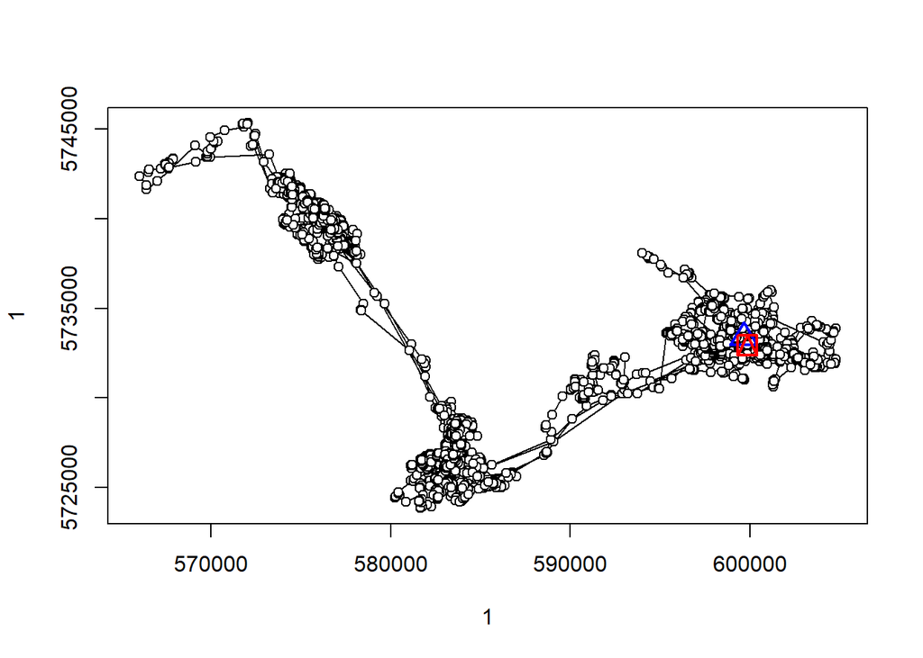

## Estimate First Passage time

```r
myelk_fpt_100 <- fpt(myelk_traj,
#'                  radii = 100,
#'                  units="hours")
#' myelk_fpt_1000 <- fpt(myelk_traj,
#'                  radii = 1000,
#'                  units="hours")
#' myelk_fpt_10000 <- fpt(myelk_traj,
#'                  radii = 10000,
#'                  units="hours")
```

Compare athese:

```r
plot(myelk_fpt_100, scale = 100)
```

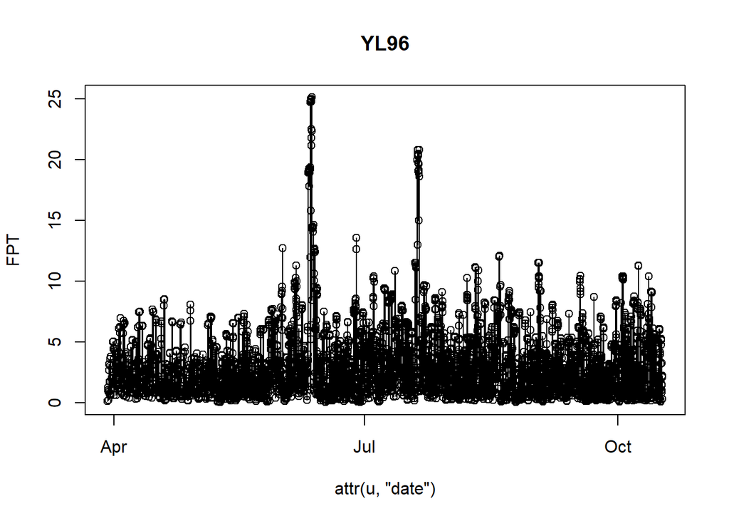

```r
plot(myelk_fpt_1000, scale = 1000)
```

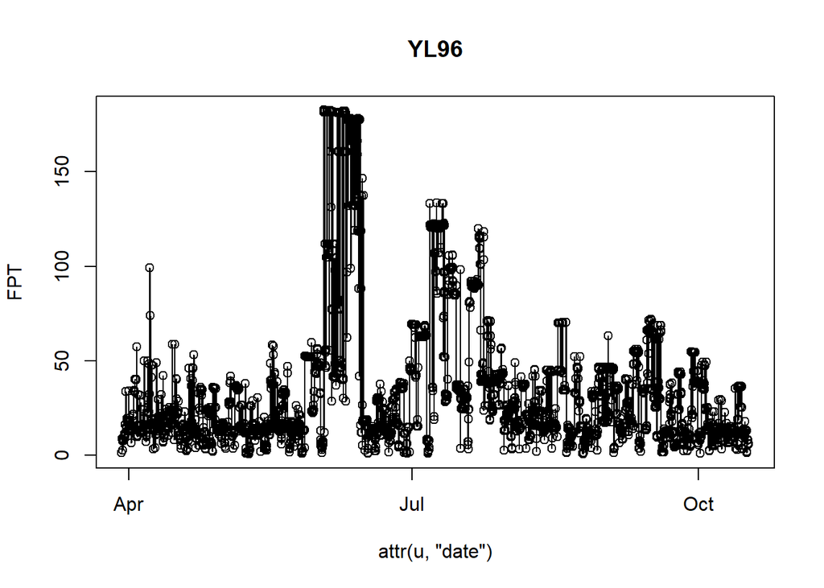

```r
plot(myelk_fpt_10000, scale = 10000)
```

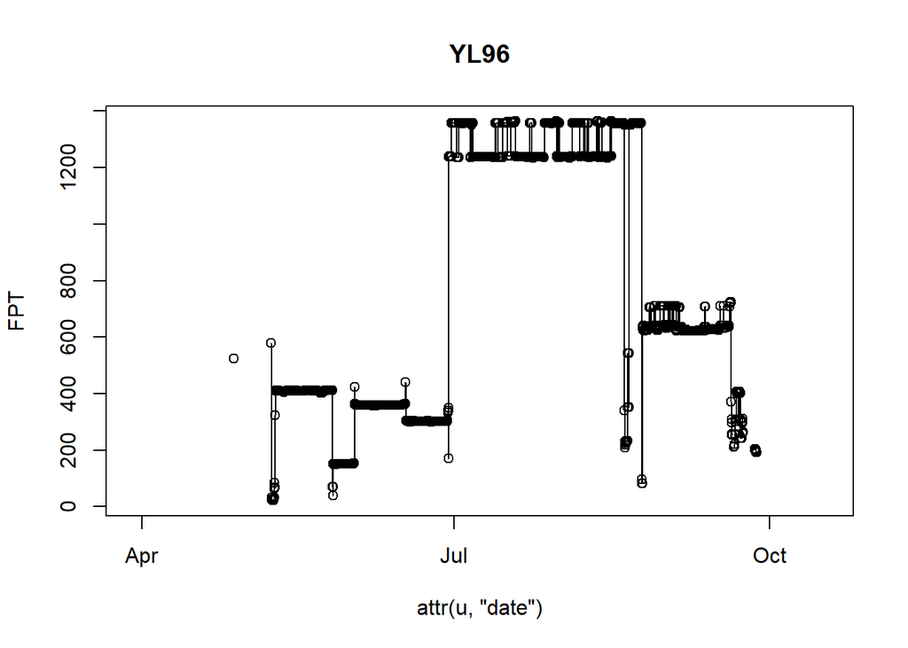

> How do you interpret these!?

A common way to “select a scale” for the first passage tima analysis #' is to compare the *variance* of the first passage time across #' many scales. We find the FPT actoss all the scales at once, and use the #' `varlogfpt` function on our FPT object to see if we can find #' a peak in the variance at one of the spatial scales of interest.

```r
myelk_fpt <- fpt(myelk_traj, radii = seq(100,10000,100))
#' varlogfpt(myelk_fpt, graph=TRUE)
```

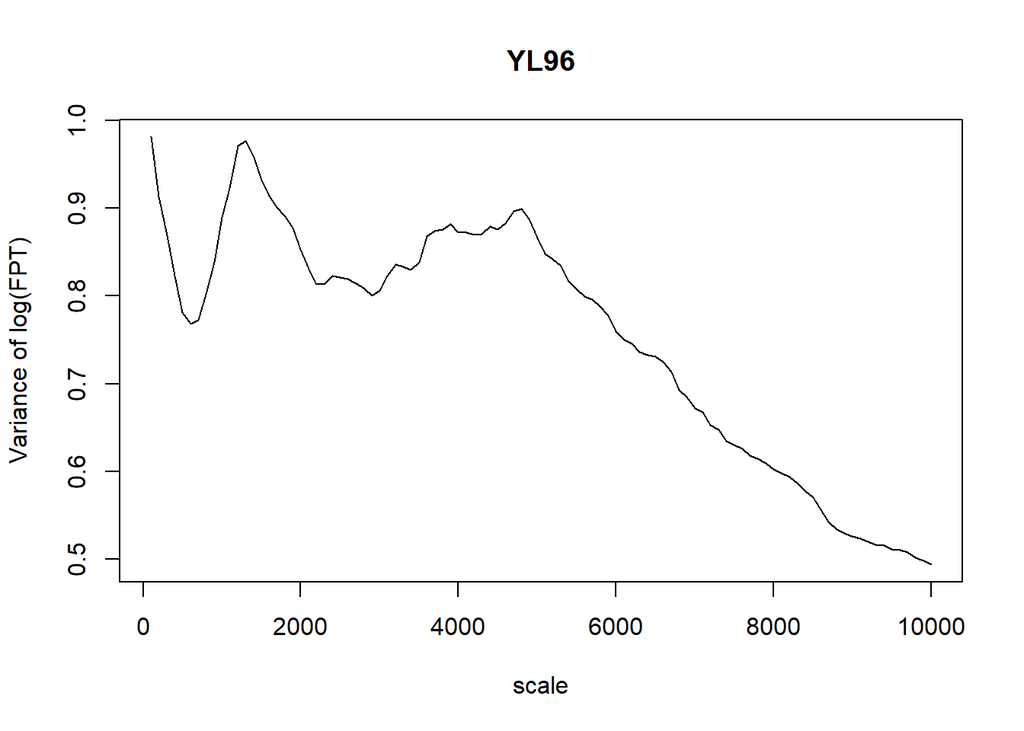

Now that we have decided on our spatial scale of interest, we can #' refit our `fpt` function and plot the results.

```r
myelk_fpt <- fpt(myelk_traj, radii = 5000, units="hours")
#' plot(myelk_fpt, scale = 5000, warn = FALSE)
```

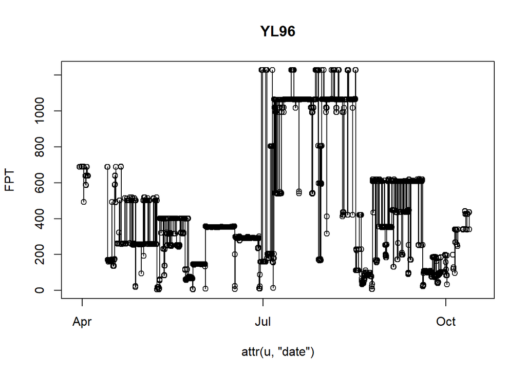

We can bind our FPT values to our data as a column by extracting it #' from our FPT object.

```r
myelk$FPT <- myelk_fpt[[1]]$r1
```

Periods of higher FPT seem to mostly correspond to the distinct #' patches of possible “residential” behavior.

```r
library(ggplot2)
```

```r
ggplot(myelk, aes(lon, lat, col = FPT)) +  geom_point() +
#'   ggtitle("First Passage Time at 5000 m radius")
```

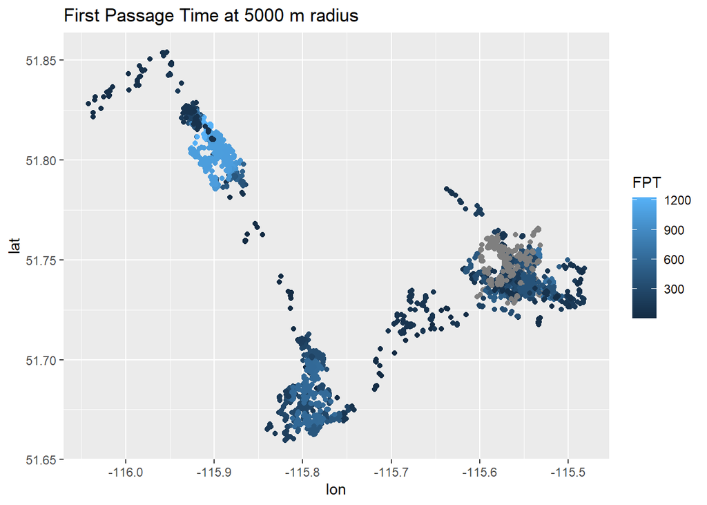

You can use a threshold here and try to pick out the periods when the #' animal is moving in a very directed way. Let’s just make this plot #' spatial as well.

```r
myelk_sf <- myelk |>
#'   st_as_sf(coords=c("lon","lat"), crs= 4326) |>
#'   mutate(FPT = myelk_fpt[[1]]$r1)
#'
#' ggplot(myelk_sf, aes(col = cut(FPT, c(0,100,200,1400)))) +
#'   geom_sf() +
#'   ggtitle("First Passage Time at 5000 m radius")
```

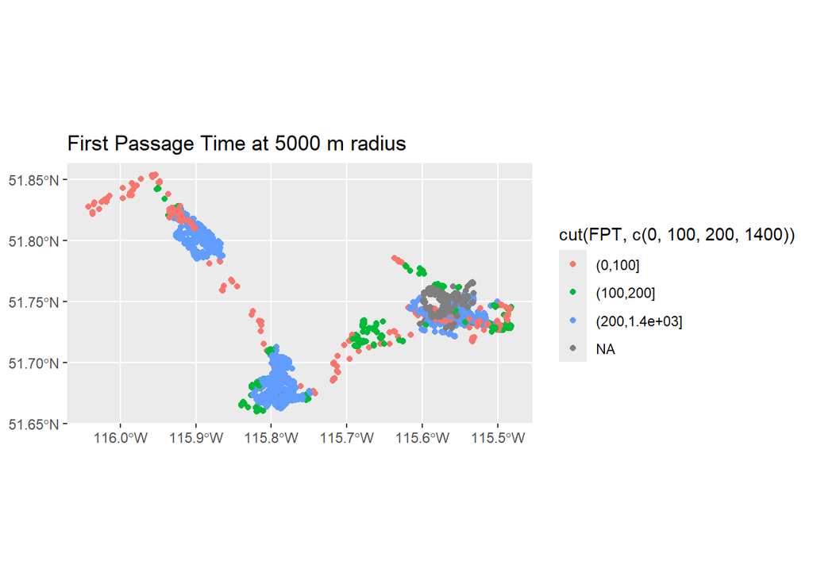

This is one way to break down the movement into very intensive, #' transitory, and intermediate “behaviors”.